# github

Jishnu Channamsetti

20/10/2020

# Establishment

The increasing trend in youth as well as the elders for the fitness bands is increasing at an alarming rate and these also serve as a cheap source of private data for the companies or organsations. These kinds of devices are particularly more famous among the fitness enthusiasts and the people who workout regularly or hit the gyms. The users of such devices usually use these devics to monitor their daily activity and to keep a track of their physical activity and ensure that they are hitting their goals and also do it right!!

# Next, we move on the most important part:the !!!!data!!!!

## as always, the first thung we do is we are loadin the !!!dtaa!!!

```r
train_jish.file   <- './data/pml-jish_train_data.csv'
test_jish.file <- './data/pml-jish_test_data.csv'
ch_train_jish.url    <- 'https://d396qusza40orc.cloudfront.net/predmachlearn/pml-training.csv'
ch_test_jish.url  <- 'https://d396qusza40orc.cloudfront.net/predmachlearn/pml-testing.csv'
#Directories
if (!file.exists("data")){
  dir.create("data")
}
if (!file.exists("data/submission")){
  dir.create("data/submission")
}

jish_iscare_insta <- require("caret")
if(!jish_iscare_insta){
    install.packages("caret")
    library("caret")
    }
jish_israndfore_insta <- require("randomForest")
if(!jish_israndfore_insta){
    install.packages("randomForest")
    library("randomForest")
    }
jish_ispartr_insta <- require("rpart")
if(!jish_ispartr_insta){
    install.packages("rpart")
    library("rpart")
    }
jish_ispartr_plot_insta <- require("rpart.plot")
if(!jish_ispartr_plot_insta){
    install.packages("rpart.plot")
    library("rpart.plot")
    }
# Set seed for reproducability
set.seed(9999)
```

## The next major step in oour project is the preprocessing of data

In this part basically we segregate the data into one part and later we slightly modify the data so that it can be used in our project and this part is called as pre-processing of data.Names of some of the variables or attributes will be changed for our benefit so that it will help in our analysis.

```r
# As discussed, we will start with downloadin the data
download.file(ch_train_jish.url, train_jish.file)
download.file(ch_test_jish.url,test_jish.file )
# Next major part of the preprocessing is the cleaning, it forms a part of the preprocessing step
jish_train_data   <-read.csv(train_jish.file, na.strings=c("NA","#DIV/0!", ""))
jish_test_data <-read.csv(test_jish.file , na.strings=c("NA", "#DIV/0!", ""))
jish_train_data<-jish_train_data[,colSums(is.na(jish_train_data)) == 0]
jish_test_data <-jish_test_data[,colSums(is.na(jish_test_data)) == 0]
# Subset data
jish_train_data   <-jish_train_data[,-c(1:7)]
jish_test_data <-jish_test_data[,-c(1:7)]
```

## The next major step in oour project is checking for cr0$$-valdaton

cr0$-valdaton is usually performed by splitting the data: in our case, jish_train_data data in jish_train_data (seventy-five%) and jish_test_data (twenty-five%).

```r
jish_sample_subs <- createDataPartition(y=jish_train_data$classe, p=0.75, list=FALSE)
sub_jish_train_data <- jish_train_data[jish_sample_subs, ]
sub_jish_test_data <- jish_train_data[-jish_sample_subs, ]
```

Now lets move ahead and form a validation in our data set for tuning:thats what we have done recently!! Guess What? currently, we have 3 segments of the data, obviously our next move is to dive into the analysis segment, but not so quick!!!! IT WAS VERY EVIDENT THAT THERE WASNT MUCH LEANING WITH RESPECT TO !!classe!!

# Examination

ITS TIME FOR SOME ANALYSIS!!! After this, we move on and we are ready to leave behind around hundred of the attributes adn hence we will be left with somethign aroynd fifty two attributes with us for the further steps.Now, lets Concentrate on one of the most fascinating features, i.e. It is to our surprise that we notice around ninthy percent of the attributes Are missing. Hence, I feel it would be wise that we leave these or drop these before moving on.

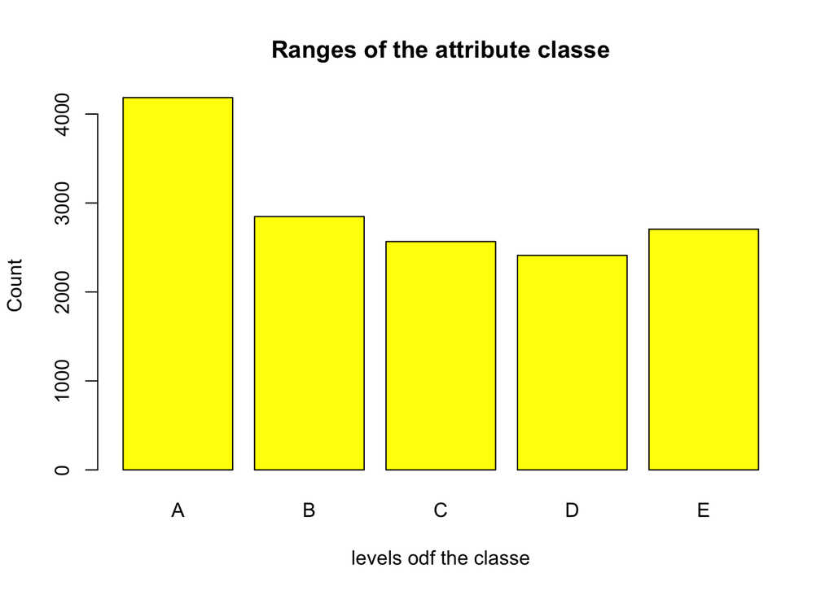

```r
plot(sub_jish_train_data$classe, col="yellow", main="Ranges of the attribute classe", xlab="levels odf the classe", ylab="Count")
```

# NOW, we are done with the graphs, hence its time for the model!!

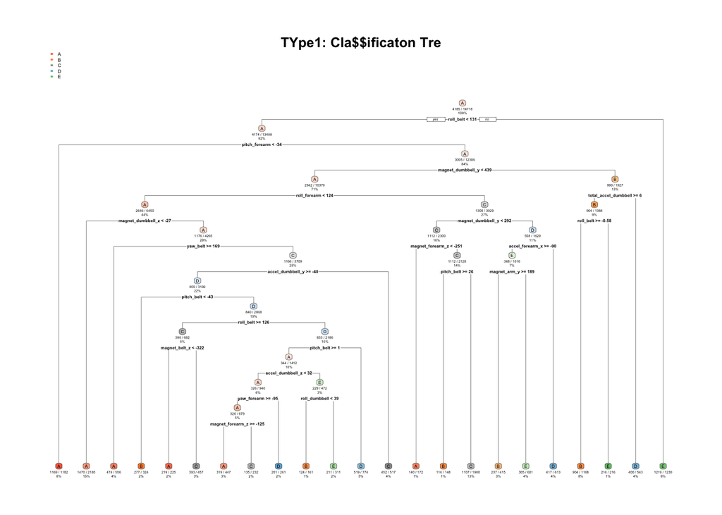

```r
# As always, the first step is always fitting the data
jish_fit_tree_mod <- rpart(classe ~ ., data=sub_jish_train_data, method="class")
# As always, the second step is always predicting the data
jish_prediction_tree_mod <- predict(jish_fit_tree_mod, sub_jish_test_data, type = "class")
# Now lets see what we have done until now by plotting
rpart.plot(jish_fit_tree_mod, main="TYpe1: Cla$$ificaton Tre", extra=102, under=TRUE, faclen=0)
```

Confusion Matrixx form a really important part in machine learning as they act as a measure of accuracy of a prediction algorithms and they can also be used as to find out the errors in our algorithm!!!!

```r
confusionMatrix(jish_prediction_tree_mod, sub_jish_test_data$classe)
```

```
## Confusion Matrix and Statistics
##
##           Reference
## Prediction    A    B    C    D    E
##          A 1247  212   23   83   30
##          B   32  530   73   23   73
##          C   35   96  695  112  121
##          D   60   66   46  532   46
##          E   21   45   18   54  631
##
## Overall Statistics
##
##                Accuracy : 0.7412
##                  95% CI : (0.7287, 0.7534)
##     No Information Rate : 0.2845
##     P-Value [Acc > NIR] : < 2.2e-16
##
##                   Kappa : 0.6712
##
##  Mcnemar's Test P-Value : < 2.2e-16
##
## Statistics by Class:
##
##                      Class: A Class: B Class: C Class: D Class: E
## Sensitivity            0.8939   0.5585   0.8129   0.6617   0.7003
## Specificity            0.9008   0.9492   0.9101   0.9468   0.9655
## Pos Pred Value         0.7818   0.7250   0.6563   0.7093   0.8205
## Neg Pred Value         0.9553   0.8996   0.9584   0.9345   0.9347
## Prevalence             0.2845   0.1935   0.1743   0.1639   0.1837
## Detection Rate         0.2543   0.1081   0.1417   0.1085   0.1287
## Detection Prevalence   0.3252   0.1491   0.2159   0.1529   0.1568
## Balanced Accuracy      0.8974   0.7538   0.8615   0.8043   0.8329
```

## we next move on to forests:random ones

```r
# As always, the first step is always fitting the data
jish_fit_forest_mod <- randomForest(classe ~ ., data=sub_jish_train_data, method="class")
# Perform prediction
jish_prediction_forest_mod <- predict(jish_fit_forest_mod, sub_jish_test_data, type = "class")
```

Confusion Matrixx form a really important part in machine learning as they act as a measure of accuracy of a prediction algorithms and they can also be used as to find out the errors in our algorithm!!!!

```r
confusionMatrix(jish_prediction_forest_mod, sub_jish_test_data$classe)
```

```
## Confusion Matrix and Statistics
##
##           Reference
## Prediction    A    B    C    D    E
##          A 1393    5    0    0    0
##          B    2  943    2    0    0
##          C    0    1  853    8    0
##          D    0    0    0  795    2
##          E    0    0    0    1  899
##
## Overall Statistics
##
##                Accuracy : 0.9957
##                  95% CI : (0.9935, 0.9973)
##     No Information Rate : 0.2845
##     P-Value [Acc > NIR] : < 2.2e-16
##
##                   Kappa : 0.9946
##
##  Mcnemar's Test P-Value : NA
##
## Statistics by Class:
##
##                      Class: A Class: B Class: C Class: D Class: E
## Sensitivity            0.9986   0.9937   0.9977   0.9888   0.9978
## Specificity            0.9986   0.9990   0.9978   0.9995   0.9998
## Pos Pred Value         0.9964   0.9958   0.9896   0.9975   0.9989
## Neg Pred Value         0.9994   0.9985   0.9995   0.9978   0.9995
## Prevalence             0.2845   0.1935   0.1743   0.1639   0.1837
## Detection Rate         0.2841   0.1923   0.1739   0.1621   0.1833
## Detection Prevalence   0.2851   0.1931   0.1758   0.1625   0.1835
## Balanced Accuracy      0.9986   0.9963   0.9977   0.9942   0.9988
```

## Conclusion

### Expected out-of-sample error

The expected out-of-sample error is estimated at 0.005, or 0.5%. The expected out-of-sample error is calculated as 1 - accuracy for predictions made against the cross-validation set. Our Test data set comprises 20 cases. With an accuracy above 99% on our cross-validation data, we can expect that very few, or none, of the test samples will be missclassified.

# Time for declaration!!!!

After testing the dataset on different models, we have come to a conclusion that the random forest is the best possible approach of all the given approaches that we have tried today. Now, let us validate the accuracy of this random forest algorithm on the test dataset

```r
# Lets start with the most important and teh first step, i.e. prediction
jish_prediction_for_subm <- predict(jish_fit_forest_mod, jish_test_data, type="class")
jish_prediction_for_subm
```

```
##  1  2  3  4  5  6  7  8  9 10 11 12 13 14 15 16 17 18 19 20
##  B  A  B  A  A  E  D  B  A  A  B  C  B  A  E  E  A  B  B  B
## Levels: A B C D E
```

```r
# Lets do the most important and the second step, i.e. noting down everything and documenting
jish_file_pml_write = function(x){
  numberrruuu = length(x)
  for(i in 1:numberrruuu){
    filename = paste0("./data/submission/problem_id_",i,".txt")
    write.table(x[i],file=filename,quote=FALSE,row.names=FALSE,col.names=FALSE)
  }
}
jish_file_pml_write(jish_prediction_for_subm)
```